# Beta Diversity

Daniyal Tariq

2024-04-30

##Goals

1.Load in phyloseq data with rooted tree. 2.Evaluate sequencing depth and remove sample. 3.Normalize the read counts between samples. 4.Calculate community dissimilarities. Numbers between 0 and 1. If 0, completely similar versus if they are 1, then they’re completely dissimilar. a.Sorensen: Shared Species as a binary value: Abundance-unweighted b.Bray-Curtis: Shared Abundant species: Abundance-weighted c.(Abundance-)Weighted UNIFRAC: Consider Abundant Species and where they fall on the tree 5.Visualize the community data with two unconstrained Ordinations: a.PCoA: Linear Method. Eigenvalue = how much variation is explained by each axis. Choose to view axis 1, 2, 3, etc. and plot them together. b.NMDS: Non-linear. Smush multiple Dimensions into 2 or 3 axes. Need to report Stress value (ideally <0.15). 6.Run statistics with PERMANOVA and betadispR.

##Set the seed

```r
set.seed(2443)
```

##Load Libraries

```r
#install.packages("vegan")
pacman::p_load(tidyverse, devtools, phyloseq, patchwork, vegan,
               install = FALSE)

lakesite_colors <- c("110" = "dodgerblue4","M15" = "dodgerblue2","M45" = "#D9CC3C","MLB" = "#A0E0BA")
```

##Load Data

```r
# Load in rooted phylogenetic tree!
load("data/03_Phylogenetic_Tree/phytree_preprocessed_physeq.RData")
```

##Explore Read Counts for combined DNA/RNA physeq

```r
# Calculate the total number of reads per sample.
raw_TotalSeqs_df  <-
  midroot_physeq %>%
  # calculate the sample read sums
  sample_sums() %>%
  data.frame()
# name the column
colnames(raw_TotalSeqs_df)[1] <- "TotalSeqs"

head(raw_TotalSeqs_df)
```

```
##            TotalSeqs
## 110D2W115D     13235
## 110D2W115R     12953
## 110D2W415D     14765
## 110D2W415R     11587
## 110D2W515D     18867
## 110D2W515R     12432
```

##Exploring Read Counts for DNA samples physeq

```r
raw_TotalSeqs_df_DNA  <-
  midroot_physeq_DNA %>%
  # calculate the sample read sums
  sample_sums() %>%
  data.frame()
# name the column
colnames(raw_TotalSeqs_df_DNA)[1] <- "TotalSeqs"

head(raw_TotalSeqs_df_DNA)
```

```
##            TotalSeqs
## 110D2W115D     13235
## 110D2W415D     14765
## 110D2W515D     18867
## 110D2W615D      9289
## 110D2W715D     14757
## 110D2W815D     36720
```

##Exploring Read Counts for RNA samples physeq

```r
raw_TotalSeqs_df_RNA  <-
  midroot_physeq_RNA %>%
  # calculate the sample read sums
  sample_sums() %>%
  data.frame()
# name the column
colnames(raw_TotalSeqs_df_RNA)[1] <- "TotalSeqs"

head(raw_TotalSeqs_df_RNA)
```

```
##            TotalSeqs
## 110D2W115R     12953
## 110D2W415R     11587
## 110D2W515R     12432
## 110D2W615R     16887
## 110D2W715R     14711
## 110D2W815R     10574
```

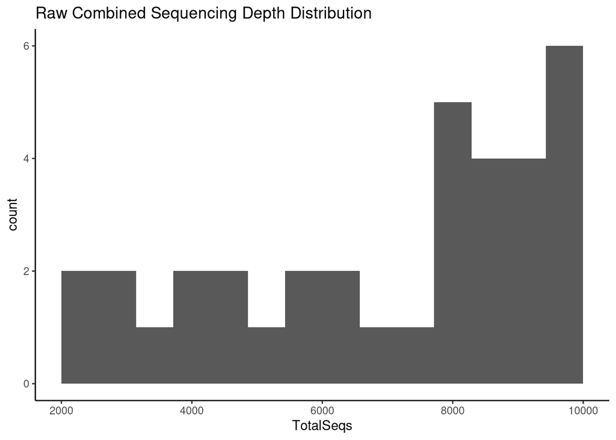

```r
# make histogram of raw reads combined
raw_TotalSeqs_df %>%
  ggplot(aes(x = TotalSeqs)) +
  geom_histogram(bins = 15) +
  scale_x_continuous(limits = c(2000, 10000)) +
  labs(title = "Raw Combined Sequencing Depth Distribution") +
  theme_classic()
```

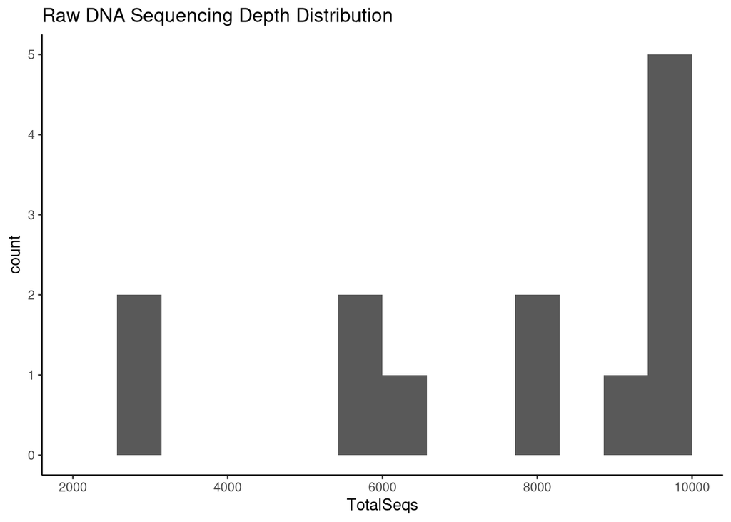

```r
# make histogram of raw reads DNA
raw_TotalSeqs_df_DNA %>%
  ggplot(aes(x = TotalSeqs)) +
  geom_histogram(bins = 15) +
  scale_x_continuous(limits = c(2000, 10000)) +
  labs(title = "Raw DNA Sequencing Depth Distribution") +
  theme_classic()
```

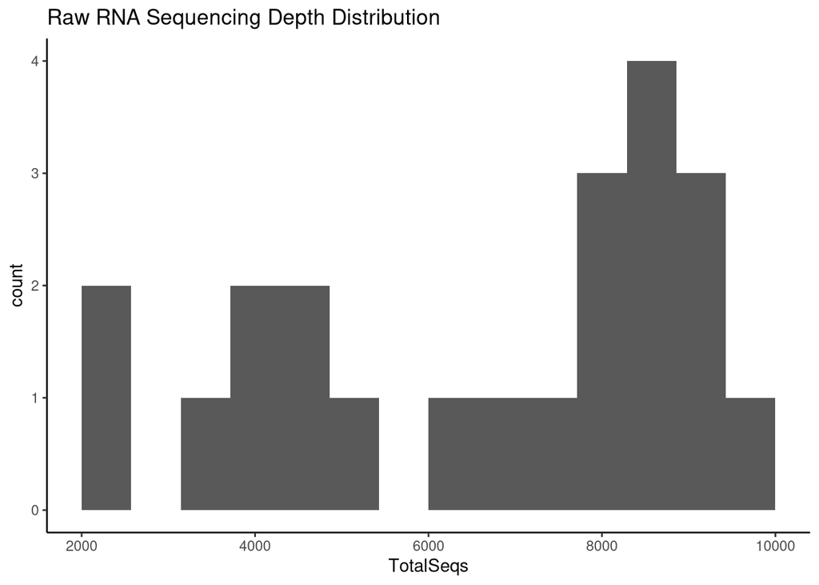

```r
# make histogram of raw reads RNA
raw_TotalSeqs_df_RNA %>%
  ggplot(aes(x = TotalSeqs)) +
  geom_histogram(bins = 15) +
  scale_x_continuous(limits = c(2000, 10000)) +
  labs(title = "Raw RNA Sequencing Depth Distribution") +
  theme_classic()
```

```r
# what is the minimum number of sequences
midroot_physeq %>%
  sample_sums() %>%
  min()
```

```
## [1] 2142
```

```r
midroot_physeq_DNA %>%
  sample_sums() %>%
  min()
```

```
## [1] 2582
```

```r
midroot_physeq_RNA %>%
  sample_sums() %>%
  min()
```

```
## [1] 2142
```

##Normalize read counts

```r
# Function to scale reads: http://deneflab.github.io/MicrobeMiseq/
# Scales reads by
# 1) taking proportions
# 2) multiplying by a given library size of n
# 3) rounding
# Default for n is the minimum sample size in your library
# Default for round is floor

matround <- function(x){trunc(x+0.5)}

scale_reads <- function(physeq, n = min(sample_sums(physeq)), round = "round") {

  # transform counts to n
  physeq.scale <- transform_sample_counts(physeq, function(x) {(n * x/sum(x))})

  # Pick the rounding functions
  if (round == "floor"){
    otu_table(physeq.scale) <- floor(otu_table(physeq.scale))
  } else if (round == "round"){
    otu_table(physeq.scale) <- round(otu_table(physeq.scale))
  } else if (round == "matround"){
    otu_table(physeq.scale) <- matround(otu_table(physeq.scale))
  }

  # Prune taxa and return new phyloseq object
  physeq.scale <- prune_taxa(taxa_sums(physeq.scale) > 0, physeq.scale)
  return(physeq.scale)
}
```

##Scale the reads and check the distribution of the seq depth

```r
min(sample_sums(midroot_physeq))
```

```
## [1] 2142
```

```r
min(sample_sums(midroot_physeq_DNA))
```

```
## [1] 2582
```

```r
min(sample_sums(midroot_physeq_RNA))
```

```
## [1] 2142
```

```r
# Scale reads by the above function
scaled_rooted_physeq <- midroot_physeq %>% scale_reads(round = "matround")
scaled_rooted_physeq_DNA <- midroot_physeq_DNA %>% scale_reads(round = "matround")
scaled_rooted_physeq_RNA <- midroot_physeq_RNA %>% scale_reads(round = "matround")

# Calculate the read depth
scaled_TotalSeqs_df <- scaled_rooted_physeq %>% sample_sums() %>% data.frame()
scaled_TotalSeqs_df_DNA <- scaled_rooted_physeq_DNA %>% sample_sums() %>% data.frame()
scaled_TotalSeqs_df_RNA <- scaled_rooted_physeq_RNA %>% sample_sums() %>% data.frame()

colnames(scaled_TotalSeqs_df)[1] <-"TotalSeqs"
colnames(scaled_TotalSeqs_df_DNA)[1] <-"TotalSeqs"
colnames(scaled_TotalSeqs_df_RNA)[1] <-"TotalSeqs"

# Inspect
head(scaled_TotalSeqs_df)
```

```
##            TotalSeqs
## 110D2W115D      2143
## 110D2W115R      2130
## 110D2W415D      2137
## 110D2W415R      2140
## 110D2W515D      2146
## 110D2W515R      2147
```

```r
head(scaled_TotalSeqs_df_DNA)
```

```
##            TotalSeqs
## 110D2W115D      2581
## 110D2W415D      2583
## 110D2W515D      2584
## 110D2W615D      2586
## 110D2W715D      2583
## 110D2W815D      2568
```

```r
head(scaled_TotalSeqs_df_RNA)
```

```
##            TotalSeqs
## 110D2W115R      2130
## 110D2W415R      2140
## 110D2W515R      2147
## 110D2W615R      2138
## 110D2W715R      2142
## 110D2W815R      2135
```

```r
# Check the range of the data
min_seqs <- min(scaled_TotalSeqs_df$TotalSeqs); min_seqs
```

```
## [1] 2117
```

```r
max_seqs <- max(scaled_TotalSeqs_df$TotalSeqs); max_seqs
```

```
## [1] 2173
```

```r
max_seqs - min_seqs
```

```
## [1] 56
```

```r
min_seqs_DNA <- min(scaled_TotalSeqs_df_DNA$TotalSeqs); min_seqs
```

```
## [1] 2117
```

```r
max_seqs_DNA <- max(scaled_TotalSeqs_df_DNA$TotalSeqs); max_seqs
```

```
## [1] 2173
```

```r
max_seqs_DNA - min_seqs_DNA
```

```
## [1] 27
```

```r
min_seqs_RNA <- min(scaled_TotalSeqs_df_RNA$TotalSeqs); min_seqs
```

```
## [1] 2117
```

```r
max_seqs_RNA <- max(scaled_TotalSeqs_df_RNA$TotalSeqs); max_seqs
```

```
## [1] 2173
```

```r
max_seqs_RNA - min_seqs_RNA
```

```
## [1] 44
```

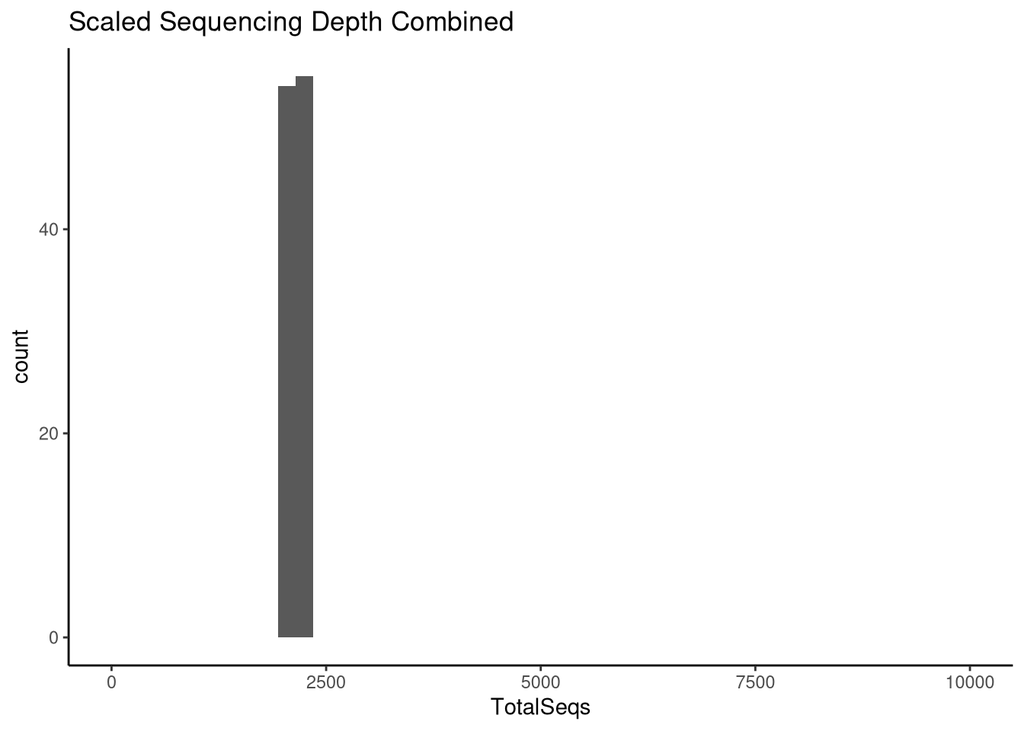

```r
# Plot Histogram
scaled_TotalSeqs_df %>%
  ggplot(aes(x = TotalSeqs)) +
  geom_histogram(bins = 50) +
  scale_x_continuous(limits = c(0, 10000)) +
  labs(title = "Scaled Sequencing Depth Combined") +
  theme_classic()
```

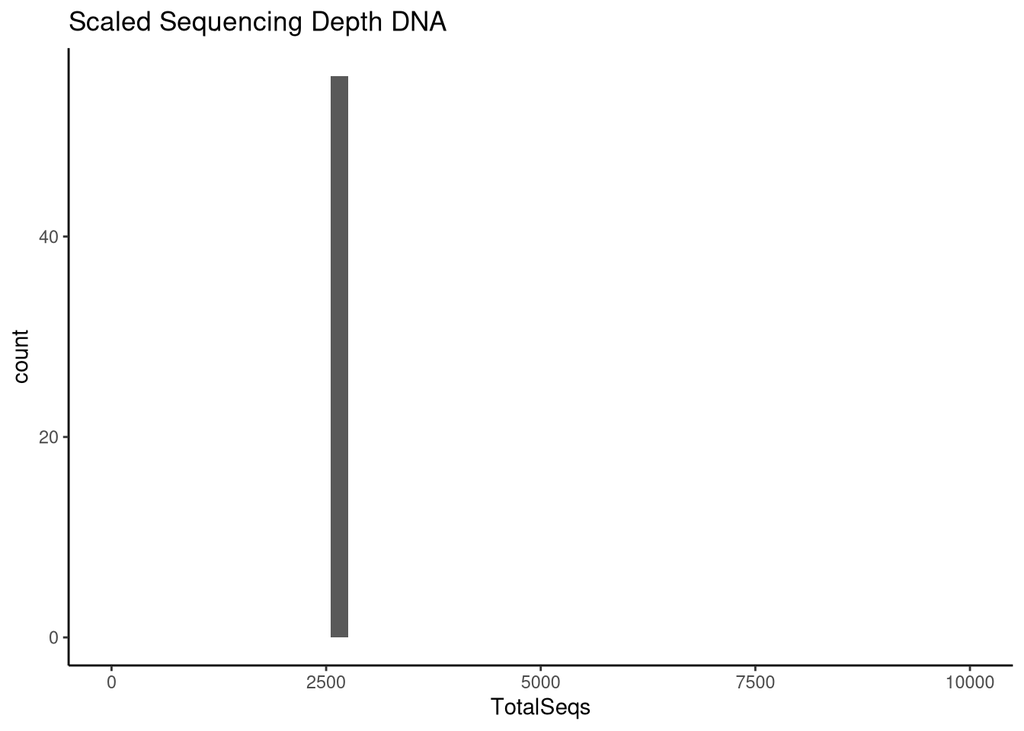

```r
scaled_TotalSeqs_df_DNA %>%
  ggplot(aes(x = TotalSeqs)) +
  geom_histogram(bins = 50) +
  scale_x_continuous(limits = c(0, 10000)) +
  labs(title = "Scaled Sequencing Depth DNA") +
  theme_classic()
```

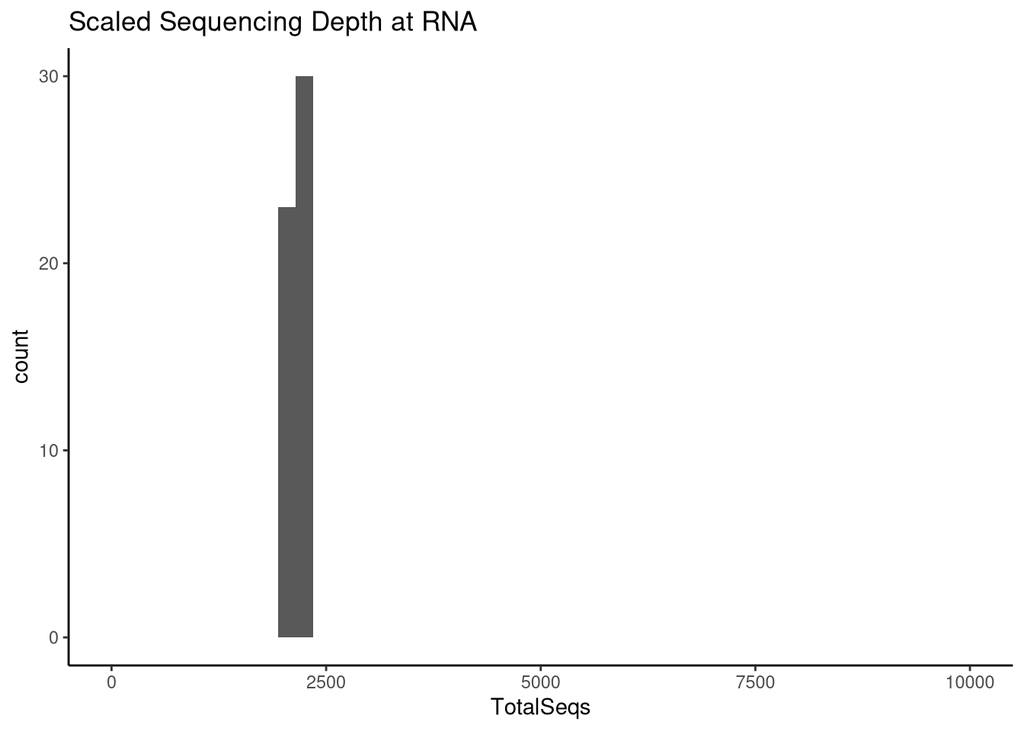

```r
scaled_TotalSeqs_df_RNA %>%
  ggplot(aes(x = TotalSeqs)) +
  geom_histogram(bins = 50) +
  scale_x_continuous(limits = c(0, 10000)) +
  labs(title = "Scaled Sequencing Depth at RNA") +
  theme_classic()
```

##Calculate & Visualize community dissimilarity

#PCoA

Sorensen

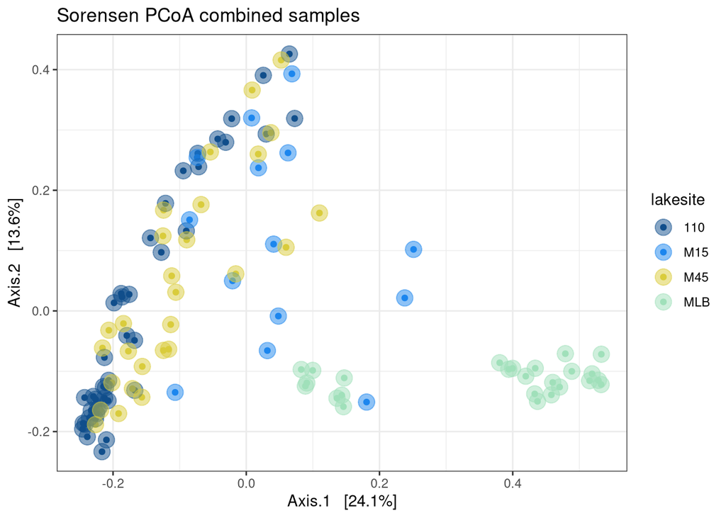

```r
# Calculate sorensen dissimilarity: Abundance-unweighted of shared taxa
scaled_soren_pcoa_combined <-
  ordinate(
    physeq = scaled_rooted_physeq,
    method = "PCoA",
    distance = "bray", binary = TRUE)

scaled_soren_pcoa_DNA <-
  ordinate(
    physeq = scaled_rooted_physeq_DNA,
    method = "PCoA",
    distance = "bray", binary = TRUE)

scaled_soren_pcoa_RNA <-
  ordinate(
    physeq = scaled_rooted_physeq_RNA,
    method = "PCoA",
    distance = "bray", binary = TRUE)

#str(scaled_soren_pcoa)

# Plot the ordination
soren_station_pcoa_combined <- plot_ordination(
  physeq = scaled_rooted_physeq,
  ordination = scaled_soren_pcoa_combined,
  color = "lakesite",
  title = "Sorensen PCoA combined samples ") +
  geom_point(size=5, alpha = 0.5, aes(color = lakesite)) +
  scale_shape_manual(values = c(15,16,17)) +
  scale_color_manual(values = lakesite_colors) +
  theme_bw()

soren_station_pcoa_DNA <- plot_ordination(
  physeq = scaled_rooted_physeq_DNA,
  ordination = scaled_soren_pcoa_DNA,
  color = "lakesite",
  title = "Sorensen PCoA DNA samples ") +
  geom_point(size=5, alpha = 0.5, aes(color = lakesite)) +
  scale_shape_manual(values = c(15,16,17)) +
  scale_color_manual(values = lakesite_colors) +
  theme_bw()

soren_station_pcoa_RNA <- plot_ordination(
  physeq = scaled_rooted_physeq_RNA,
  ordination = scaled_soren_pcoa_RNA,
  color = "lakesite",
  title = "Sorensen PCoA RNA samples ") +
  geom_point(size=5, alpha = 0.5, aes(color = lakesite)) +
  scale_shape_manual(values = c(15,16,17)) +
  scale_color_manual(values = lakesite_colors) +
  theme_bw()

# Show the plot
soren_station_pcoa_combined
```

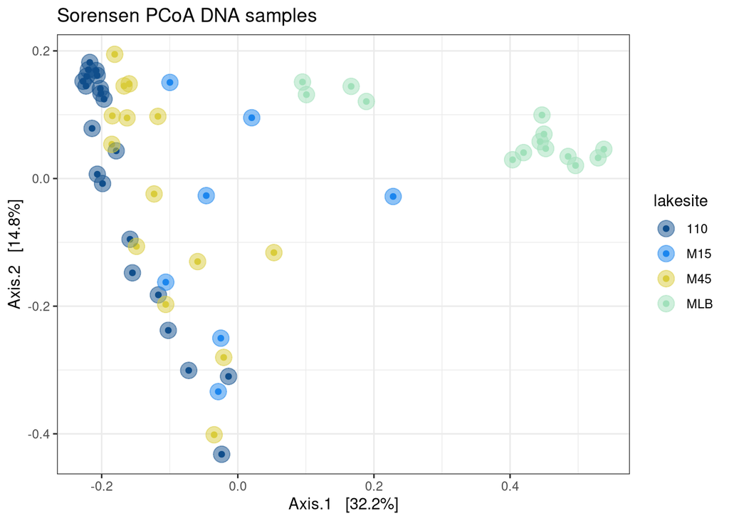

```r
soren_station_pcoa_DNA
```

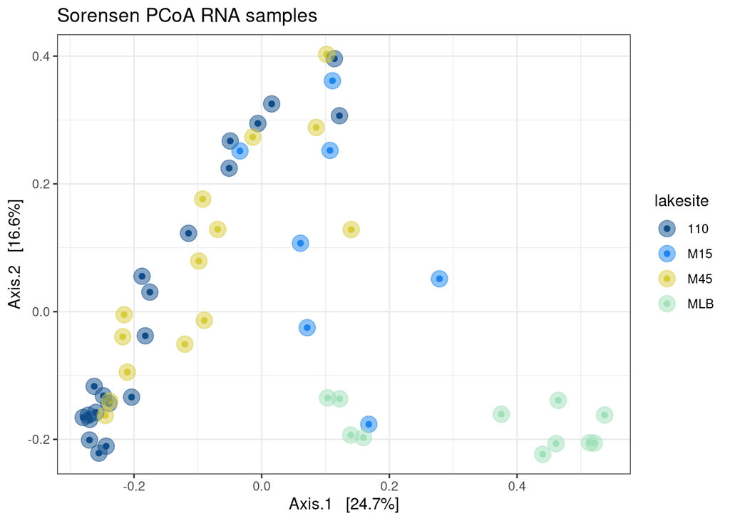

```r
soren_station_pcoa_RNA
```

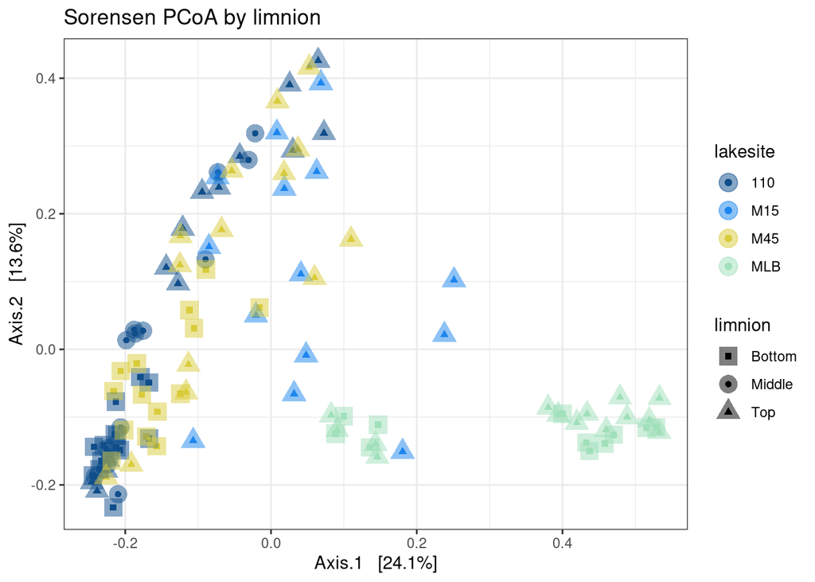

```r
# Calculate sorensen dissimilarity: Abundance-unweighted of shared taxa
scaled_soren_pcoa <-
  ordinate(
    physeq = scaled_rooted_physeq,
    method = "PCoA",
    distance = "bray", binary = TRUE)

#str(scaled_soren_pcoa)

# Plot the ordination
soren_station_pcoa <- plot_ordination(
  physeq = scaled_rooted_physeq,
  ordination = scaled_soren_pcoa,
  color = "lakesite",
  shape = "limnion",
  title = "Sorensen PCoA by limnion") +
  geom_point(size=5, alpha = 0.5, aes(color = lakesite)) +
  scale_shape_manual(values = c(15,16,17)) +
  scale_color_manual(values = lakesite_colors) +
  theme_bw()
# Show the plot
soren_station_pcoa
```

Bray

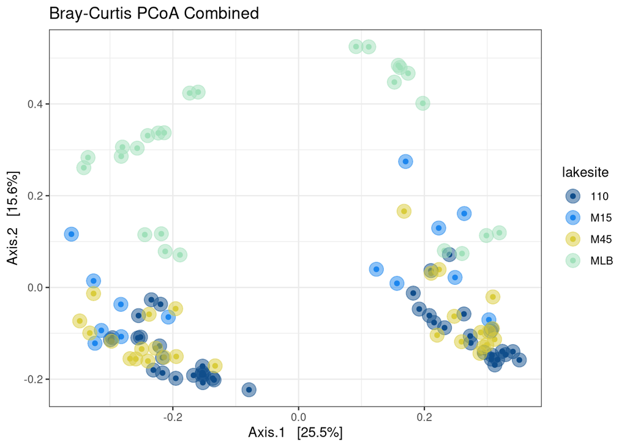

```r
# Calculate the BC distance
scaled_BC_pcoa_combined <-
  ordinate(
    physeq = scaled_rooted_physeq,
    method = "PCoA",
    distance = "bray")

scaled_BC_pcoa_DNA <-
  ordinate(
    physeq = scaled_rooted_physeq_DNA,
    method = "PCoA",
    distance = "bray")

scaled_BC_pcoa_RNA <-
  ordinate(
    physeq = scaled_rooted_physeq_RNA,
    method = "PCoA",
    distance = "bray")



# Plot the PCoA
bray_station_pcoa_combined <-
  plot_ordination(
    physeq = scaled_rooted_physeq,
    ordination = scaled_BC_pcoa_combined,
    color = "lakesite",
    title = "Bray-Curtis PCoA Combined") +
  geom_point(size=5, alpha = 0.5, aes(color = lakesite)) +
  scale_shape_manual(values = c(15,16,17,18, 19, 20,21)) +
  scale_color_manual(values = c(lakesite_colors)) +
  theme_bw()

bray_station_pcoa_DNA <-
  plot_ordination(
    physeq = scaled_rooted_physeq_DNA,
    ordination = scaled_BC_pcoa_DNA,
    color = "lakesite",
    title = "Bray-Curtis PCoA DNA") +
  geom_point(size=5, alpha = 0.5, aes(color = lakesite)) +
  scale_shape_manual(values = c(15,16,17,18, 19, 20,21)) +
  scale_color_manual(values = c(lakesite_colors)) +
  theme_bw()

bray_station_pcoa_RNA <-
  plot_ordination(
    physeq = scaled_rooted_physeq_RNA,
    ordination = scaled_BC_pcoa_RNA,
    color = "lakesite",
    title = "Bray-Curtis PCoA RNA") +
  geom_point(size=5, alpha = 0.5, aes(color = lakesite)) +
  scale_shape_manual(values = c(15,16,17,18, 19, 20,21)) +
  scale_color_manual(values = c(lakesite_colors)) +
  theme_bw()

bray_station_pcoa_combined
```

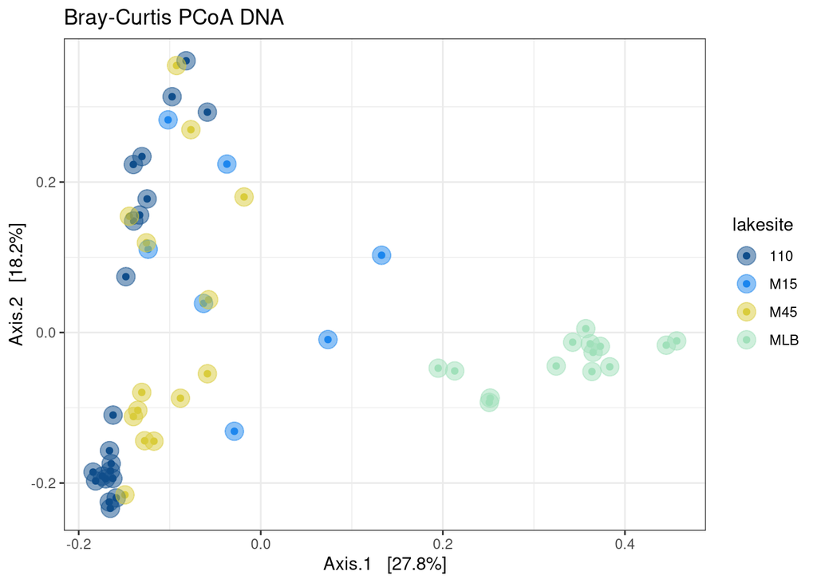

```r
bray_station_pcoa_DNA
```

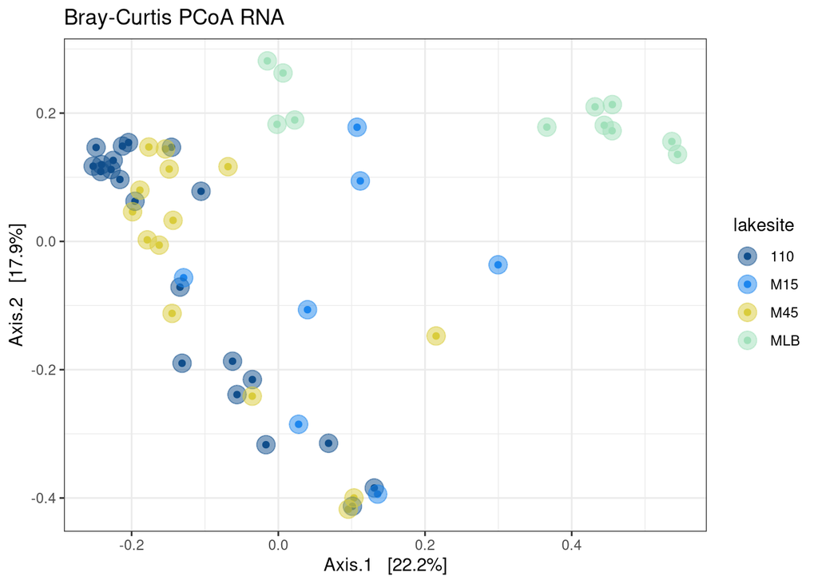

```r
bray_station_pcoa_RNA
```

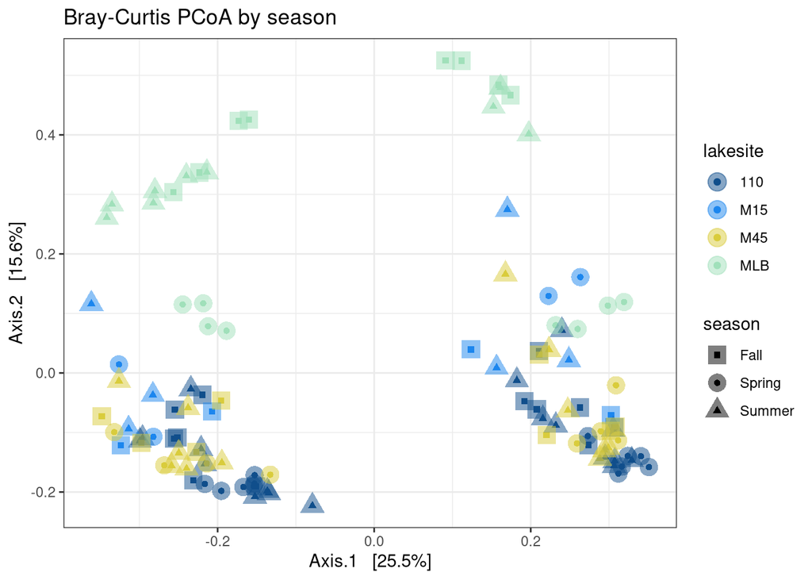

```r
# Calculate the BC distance
scaled_BC_pcoa <-
  ordinate(
    physeq = scaled_rooted_physeq,
    method = "PCoA",
    distance = "bray")

# Plot the PCoA
bray_station_pcoa <-
  plot_ordination(
    physeq = scaled_rooted_physeq,
    ordination = scaled_BC_pcoa,
    color = "lakesite",
    shape = "season",
    title = "Bray-Curtis PCoA by season") +
  geom_point(size=5, alpha = 0.5, aes(color = lakesite)) +
  scale_shape_manual(values = c(15,16,17,18, 19, 20,21)) +
  scale_color_manual(values = c(lakesite_colors)) +
  theme_bw()
bray_station_pcoa
```

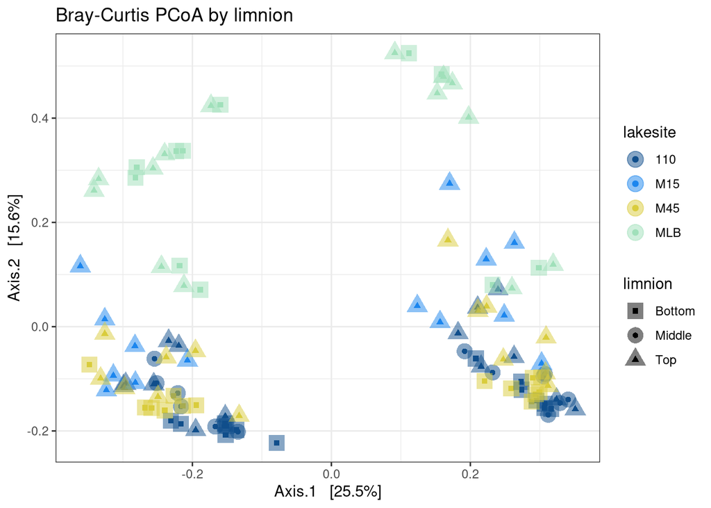

```r
# Calculate the BC distance
scaled_BC_pcoa <-
  ordinate(
    physeq = scaled_rooted_physeq,
    method = "PCoA",
    distance = "bray")

# Plot the PCoA
bray_station_pcoa <-
  plot_ordination(
    physeq = scaled_rooted_physeq,
    ordination = scaled_BC_pcoa,
    color = "lakesite",
    shape = "limnion",
    title = "Bray-Curtis PCoA by limnion") +
  geom_point(size=5, alpha = 0.5, aes(color = lakesite)) +
  scale_shape_manual(values = c(15,16,17,18, 19, 20,21)) +
  scale_color_manual(values = c(lakesite_colors)) +
  theme_bw()
bray_station_pcoa
```

Weighted Unifrac

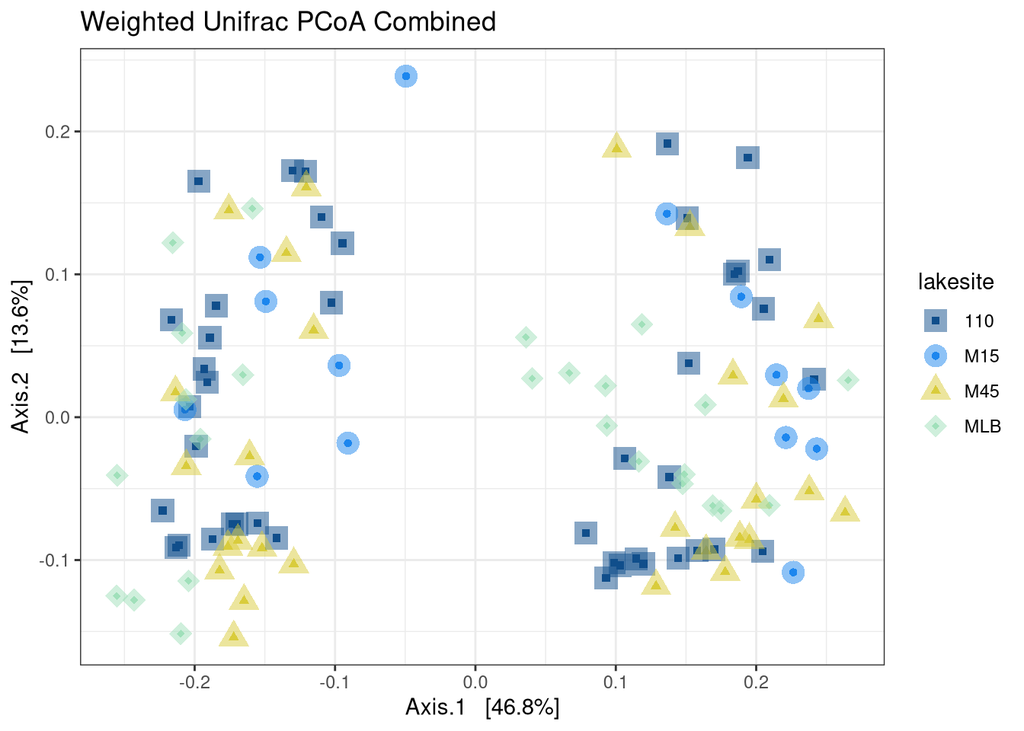

```r
# Calculate the BC distance
scaled_wUNI_pcoa_combined <-
  ordinate(
    physeq = scaled_rooted_physeq,
    method = "PCoA",
    distance = "wunifrac")

scaled_wUNI_pcoa_DNA <-
  ordinate(
    physeq = scaled_rooted_physeq_DNA,
    method = "PCoA",
    distance = "wunifrac")

scaled_wUNI_pcoa_RNA <-
  ordinate(
    physeq = scaled_rooted_physeq_RNA,
    method = "PCoA",
    distance = "wunifrac")


# Plot the PCoA
wUNI_station_pcoa_combined <-
  plot_ordination(
    physeq = scaled_rooted_physeq,
    ordination = scaled_wUNI_pcoa_combined,
    color = "lakesite",
    shape = "lakesite",
    title = "Weighted Unifrac PCoA Combined") +
  geom_point(size=5, alpha = 0.5, aes(color = lakesite)) +
  scale_shape_manual(values = c(15,16,17,18, 19, 20)) +
  scale_color_manual(values = c(lakesite_colors)) +
  theme_bw()

wUNI_station_pcoa_DNA <-
  plot_ordination(
    physeq = scaled_rooted_physeq_DNA,
    ordination = scaled_wUNI_pcoa_DNA,
    color = "lakesite",
    shape = "lakesite",
    title = "Weighted Unifrac PCoA DNA") +
  geom_point(size=5, alpha = 0.5, aes(color = lakesite)) +
  scale_shape_manual(values = c(15,16,17,18, 19, 20)) +
  scale_color_manual(values = c(lakesite_colors)) +
  theme_bw()

wUNI_station_pcoa_RNA <-
  plot_ordination(
    physeq = scaled_rooted_physeq_RNA,
    ordination = scaled_wUNI_pcoa_RNA,
    color = "lakesite",
    shape = "lakesite",
    title = "Weighted Unifrac PCoA RNA") +
  geom_point(size=5, alpha = 0.5, aes(color = lakesite)) +
  scale_shape_manual(values = c(15,16,17,18, 19, 20)) +
  scale_color_manual(values = c(lakesite_colors)) +
  theme_bw()

wUNI_station_pcoa_combined
```

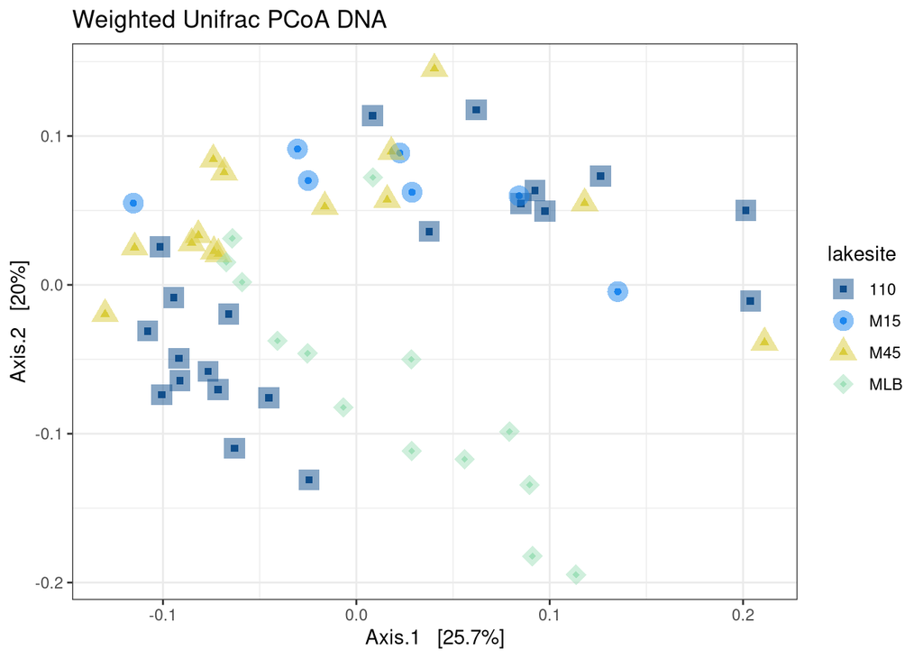

```r
wUNI_station_pcoa_DNA
```

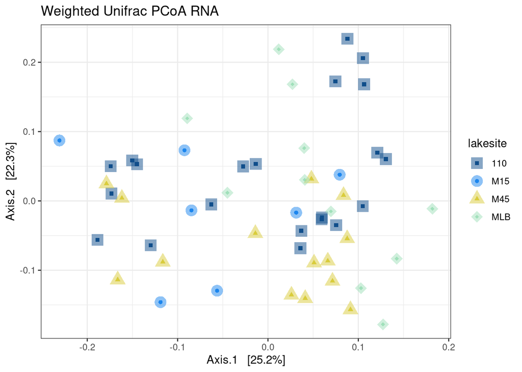

```r
wUNI_station_pcoa_RNA
```

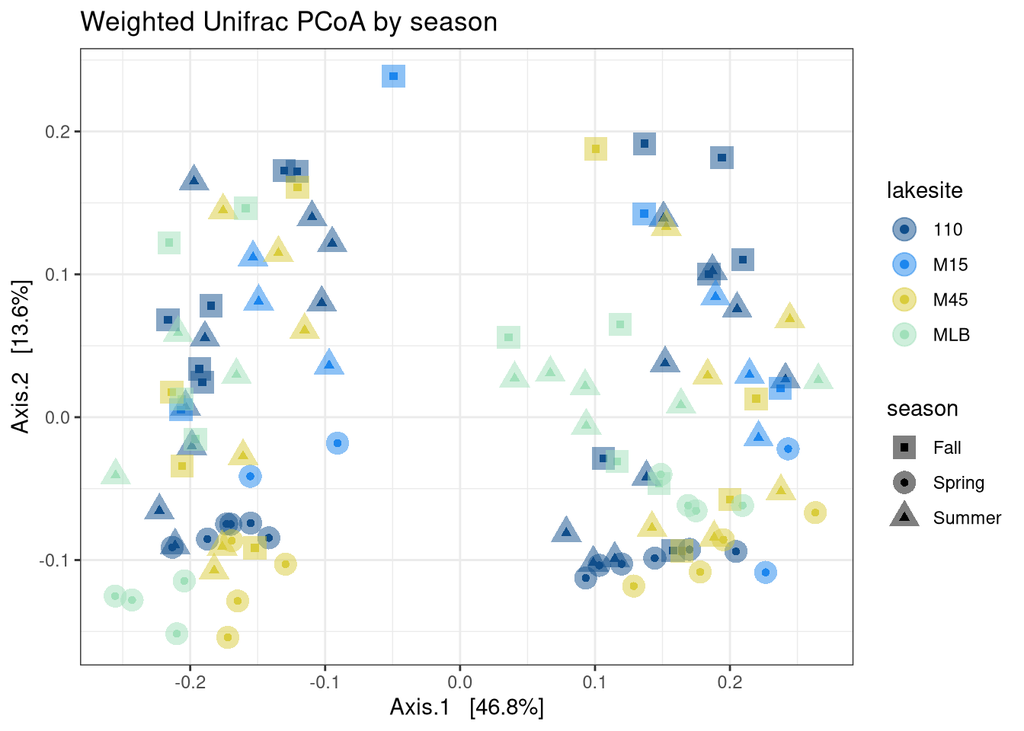

```r
# Calculate the BC distance
scaled_wUNI_pcoa <-
  ordinate(
    physeq = scaled_rooted_physeq,
    method = "PCoA",
    distance = "wunifrac")

# Plot the PCoA
wUNI_station_pcoa <-
  plot_ordination(
    physeq = scaled_rooted_physeq,
    ordination = scaled_wUNI_pcoa,
    color = "lakesite",
    shape = "season",
    title = "Weighted Unifrac PCoA by season") +
  geom_point(size=5, alpha = 0.5, aes(color = lakesite)) +
  scale_shape_manual(values = c(15,16,17)) +
  scale_color_manual(values = c(lakesite_colors)) +
  theme_bw()
wUNI_station_pcoa
```

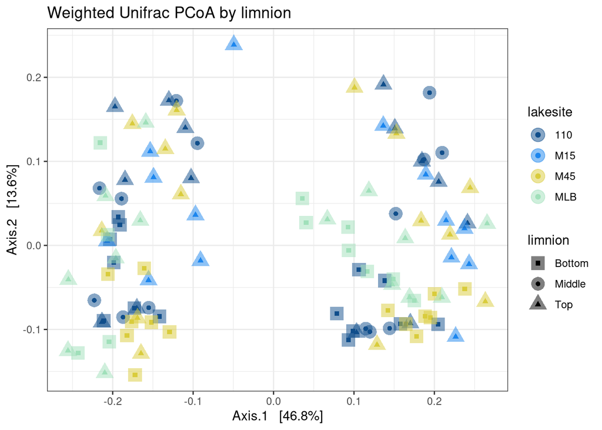

```r
# Calculate the BC distance
scaled_wUNI_pcoa <-
  ordinate(
    physeq = scaled_rooted_physeq,
    method = "PCoA",
    distance = "wunifrac")

# Plot the PCoA
wUNI_station_pcoa <-
  plot_ordination(
    physeq = scaled_rooted_physeq,
    ordination = scaled_wUNI_pcoa,
    color = "lakesite",
    shape = "limnion",
    title = "Weighted Unifrac PCoA by limnion") +
  geom_point(size=5, alpha = 0.5, aes(color = lakesite)) +
  scale_shape_manual(values = c(15,16,17)) +
  scale_color_manual(values = c(lakesite_colors)) +
  theme_bw()
wUNI_station_pcoa
```

##NMDS